# DESeq: Ovarian Cancer Cell Line RNAseq Platinum Sensitivity

## Introduction

RNA-seq was run on 36 ovarian cancer cell lines, each in singlicate.

All 36 cell lines have 72h cisplatin IC50s determined by Kristin Adams and Kendra Wendt in the Lang Lab.

```r
library(knitr)
knit("src/load_inputs.Rmd")
```

```
processing file: src/load_inputs.Rmd
```

[output not shown]

```
output file: load_inputs.md
```

```
[1] "load_inputs.md"
```

## DESeq2

### Create DESeqDataSet object dds

```r
dds <- DESeqDataSetFromMatrix(countData = countmatrix2,
                              colData = metadata,
                              design = ~ PlatinumSensitivity)
```

Don’t need to filter - this is done automatically

### Run DESeq2

```r
path = paste0(deseq_Rdata_folder,
              "/dds_HGSC_categorical.RData")

# Run DESeq
# dds <- DESeq(dds)
# save(dds, file = path)

# Alternatively, if this has already been run, can load dds object
load(path)
```

### Print DESeq results

```r
res <- results(dds, contrast=c("PlatinumSensitivity", "resistant", "sensitive"))
res
```

```
log2 fold change (MLE): PlatinumSensitivity resistant vs sensitive
Wald test p-value: PlatinumSensitivity resistant vs sensitive
DataFrame with 29744 rows and 6 columns
            baseMean log2FoldChange     lfcSE       stat      pvalue      padj
           <numeric>      <numeric> <numeric>  <numeric>   <numeric> <numeric>
A1BG      22.4540264     -0.2527125  0.861053 -0.2934924 0.769145771 0.9637933
A1BG-AS1  48.3012543     -0.0373153  0.685132 -0.0544644 0.956565132 0.9920085
A1CF       0.0619977     -0.3982964  3.331743 -0.1195459 0.904842838        NA
A2M      825.3555009     -3.6287790  1.635459 -2.2188138          NA        NA
A2M-AS1   32.1155303      2.5020680  0.662078  3.7791119 0.000157389 0.0490912
...              ...            ...       ...        ...         ...       ...
ZYG11A       544.635    -0.28555042  0.395400 -0.7221806    0.470183  0.892789
ZYG11B      2015.753    -0.46066813  0.443277 -1.0392319    0.298697  0.823076
ZYX         4542.791    -0.00937188  0.398010 -0.0235469    0.981214  0.995173
ZZEF1       1668.988     0.30860896  0.344078  0.8969161    0.369764  0.860214
ZZZ3        3769.727    -0.14459360  0.264695 -0.5462649    0.584884  0.920459
```

```r
path = paste0(deseq_output_folder,
              "/DESeq_HGSC.csv")
write.csv(as.data.frame(res), file = path)
```

### Filter DESeq2 results for significant genes

Filter res for padj < 0.05 and |log2FC| >= 1.2

```r
res.filtered <- as.data.frame(res) %>%
  filter(padj<0.05)%>%
  filter(log2FoldChange >= 1.2 | log2FoldChange <= -1.2)
res.filtered
```

|  | baseMean | log2FoldChange | lfcSE | stat | pvalue | padj |
| --- | --- | --- | --- | --- | --- | --- |
| A2M-AS1 | 3.211553e+01 | 2.502068 | 0.6620783 | 3.779112 | 1.573887e-04 | 4.909121e-02 |
| B3GALT1 | 9.917436e+01 | -4.883977 | 1.1010960 | -4.435560 | 9.183340e-06 | 6.416216e-03 |
| BARX1 | 6.264030e+01 | -4.886369 | 1.2516007 | -3.904096 | 9.457832e-05 | 3.514893e-02 |
| BTBD3 | 2.362688e+03 | -2.100629 | 0.5287319 | -3.972957 | 7.098585e-05 | 2.952166e-02 |
| CAPN9 | 4.549569e+01 | -5.598612 | 1.4540145 | -3.850451 | 1.179004e-04 | 4.037972e-02 |
| CCDC3 | 4.666491e+02 | -3.390413 | 0.8041285 | -4.216258 | 2.483900e-05 | 1.292570e-02 |
| CCL5 | 2.138581e+02 | 7.144378 | 1.1256236 | 6.347040 | 2.194969e-10 | 3.485411e-07 |
| CD70 | 3.000422e+02 | 3.960233 | 0.9914367 | 3.994439 | 6.484756e-05 | 2.831731e-02 |
| CDSN | 1.881659e+01 | 2.810676 | 0.6814453 | 4.124580 | 3.714116e-05 | 1.853556e-02 |
| CEBPA | 8.110142e+01 | -2.020593 | 0.5340511 | -3.783520 | 1.546260e-04 | 4.909121e-02 |

[output cut: 46 more lines]

## Data QC

### Data transformation

Here we performed normal transformation [log2(n+1)], variance stabilized transformation, and regularized log tranformation to improve visualization of the data values. To speed up subsequent re-runs, we have hidden analysis for non-vst.

````
```r
vsd <- vst(dds)
meanSdPlot(assay(vsd))
````

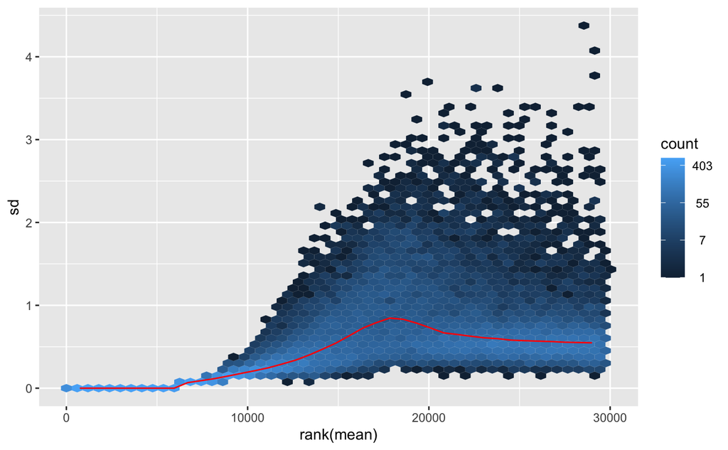

````r
```r
# ntd <- normTransform(dds)
# meanSdPlot(assay(ntd))
````

```r
vsd.df = as.data.frame(assay(vsd))
```

````r
```r
# rld <- rlog(dds)
# meanSdPlot(assay(rld))
````

[output not shown]

```
using ntop=500 top features by variance
```

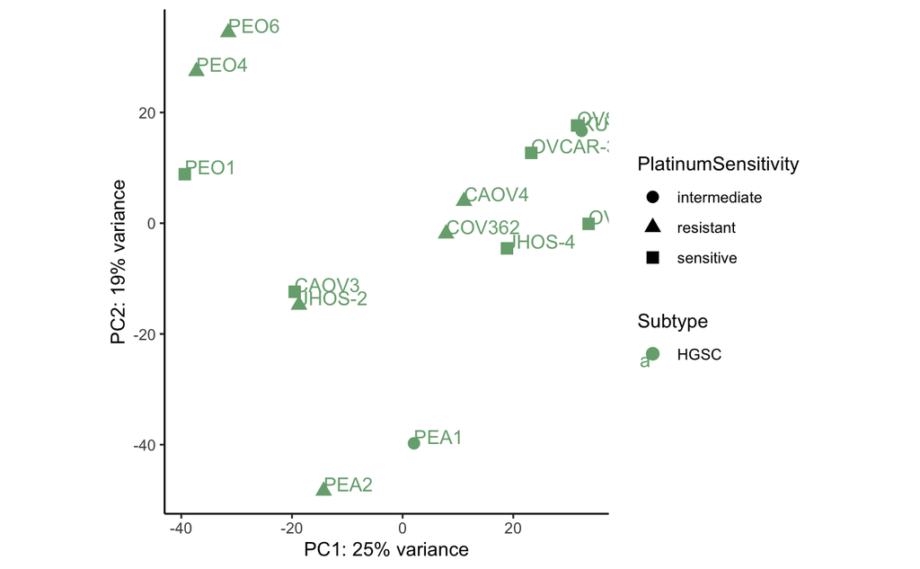

```r
percentVar <- round(100 * attr(pcaData, "percentVar"))
myColors <- c("#76AB7E", "#63E678", "#1D32FB", "#7B87FD", "#01BD1F", "#E8A426", "#0B7C1D", "#BB19E7")
names(myColors) <- levels(pcaData$Subtype)
colScale <- scale_colour_manual(name = "Subtype",values = myColors)
pca <- ggplot(pcaData, aes(PC1, PC2, color=Subtype, shape=PlatinumSensitivity, label=CellLine)) +
  geom_point(size=3) +
  geom_text(hjust=0, vjust=0) +
  xlab(paste0("PC1: ",percentVar[1],"% variance")) +
  ylab(paste0("PC2: ",percentVar[2],"% variance")) +
  coord_fixed() +
  theme_classic() +
  colScale
pca
path = paste0(deseq_output_folder,
              "/pca_HGSC.pdf")
ggsave(path, pca)
```

### Plot heatmaps to check sample to sample variability

Plotting the top 100 most highly expressed genes:

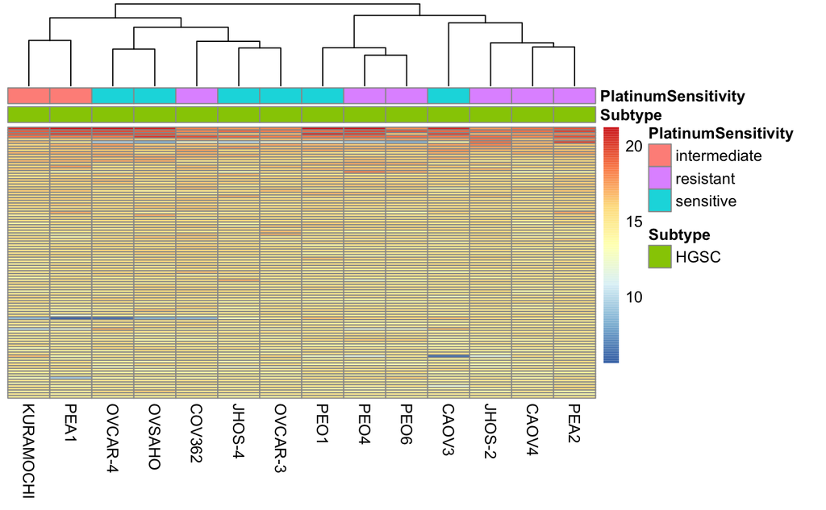

```r
select <- order(rowMeans(counts(dds,normalized=TRUE)),
                decreasing=TRUE)[1:100]
df <- as.data.frame(colData(dds)[,c("Subtype", "PlatinumSensitivity")])
pheatmap(assay(vsd)[select,], cluster_rows=FALSE, show_rownames=FALSE,
         labels_col=colData(dds)[,c("CellLine")],annotation_col=df)
```

### Dendrogram based on gene expression

Pull genes contributing to principal components 1 & 2

````r
```r
# Not sure what this was for:
# PCA <- prcomp(TPM.log, scale=TRUE)
# PCA.mat <- as.data.frame(PCA$x)
# PCA.PC1filt <- PCA.mat %>% filter(PC1 < quantile(PCA.mat[,\PC1\], .2)[[1]])
````

````
```r
TPM3 <- TPM2[rowSums(TPM2)>1000, metadata$CellLine]
counts.sc <- t(TPM3)
dist <- dist(counts.sc)
clust <- hclust(dist, method="average")
dend1 <- as.dendrogram(clust)
````

[figure not shown]

```r
par(mar=c(10,2,1,1))
my_colors <- ifelse(metadata$PlatinumSensitivity=="sensitive", "red",
                    ifelse(metadata$PlatinumSensitivity=="resistant", "blue",
                           ifelse(metadata$PlatinumSensitivity=="intermediate", "yellow", "white" )))
plot(dend1)
colored_bars(colors = my_colors, dend = dend1, rowLabels = "PlatinumSensitivity")
```

I tried a lot of different iterations of this (including: various cutoffs for variance of genes, genes contributing most to first and second principal components, more highly expressed genes, TPM vs vst data, clustering methods), but the fundamental problem is that isogenic pairs rarely cluster anywhere near each other, even though the PCA analysis shows this relationship. I don’t know that this is a reliable method for determining relatedness/subtyping, unless a robust gene set is developed.(This is from Jessi)

## Data visualization

### Plot Heatmap of top differentially expressed genes

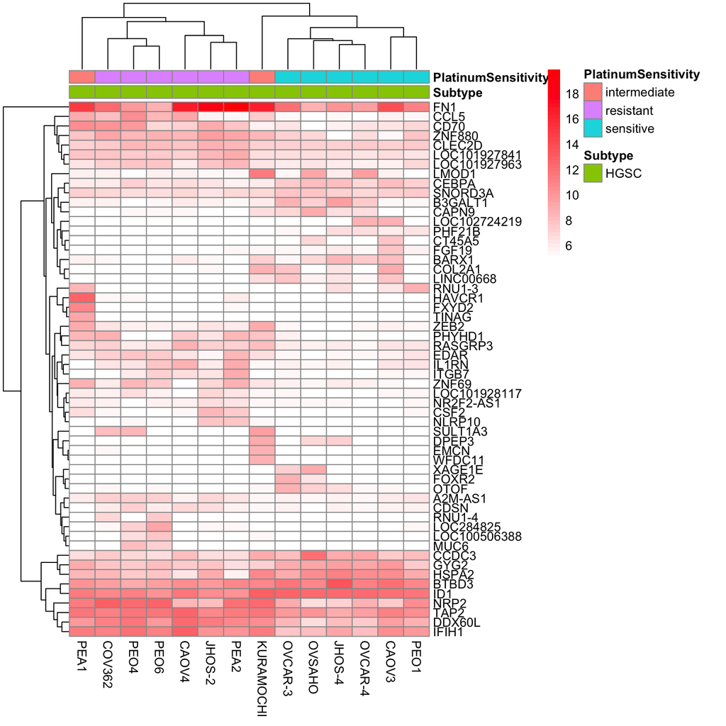

```r
vsd.df <-as.data.frame(assay(vsd))
pheatmap(vsd.df[rownames(res.filtered),], labels_col=colData(dds)[,c("CellLine")],annotation_col=df, color=colorRampPalette(c("white", "red"))(50))
```

### Heatmap based on TPM

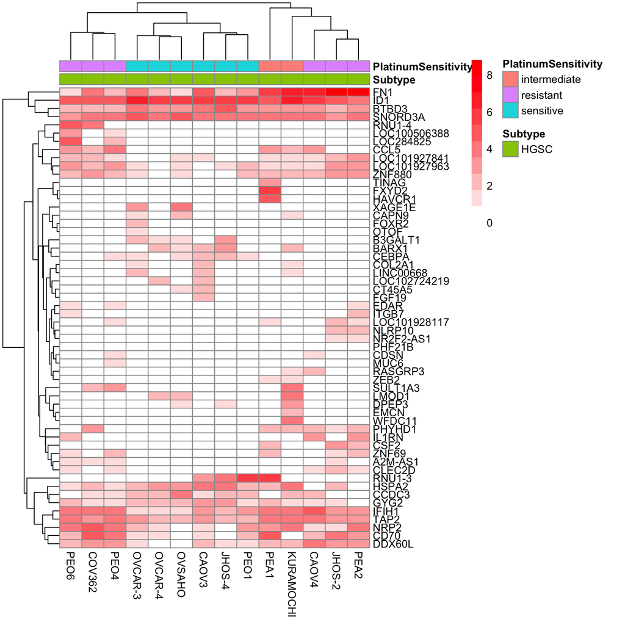

```r
pheatmap(TPM.log[rownames(res.filtered),], labels_col=colData(dds)[,c("CellLine")], annotation_col=df, color=colorRampPalette(c("white", "red"))(10))
```

### Heatmap with mean-centered data

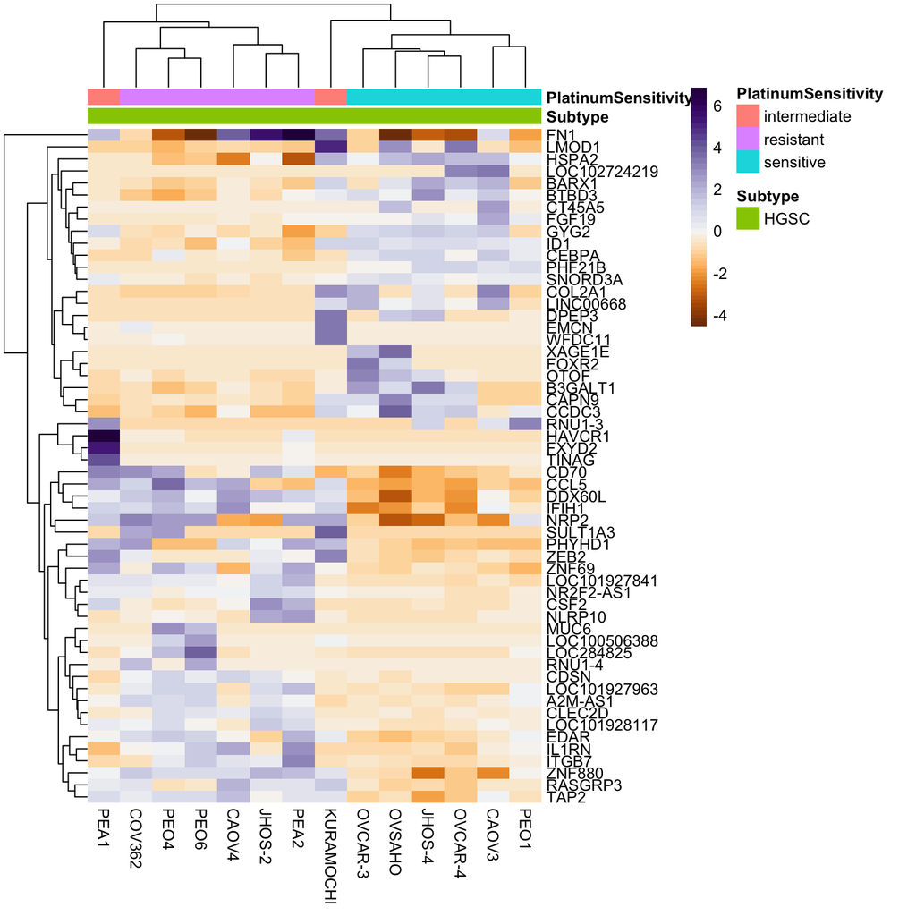

```r
center_scale <- function(x) {
  scale(x, scale=FALSE)
}
vsd.meancenter <- apply(vsd.df, 1, center_scale)
vsd.meancenter <-t(vsd.meancenter)
colnames(vsd.meancenter) <- colnames(vsd.df)
vsd.meancenter <- as.data.frame(vsd.meancenter)
color <- colorRampPalette(brewer.pal(11, "PuOr"))(50)
myBreaks <- c(seq(min(vsd.meancenter[rownames(res.filtered),]), 0, length.out=ceiling(50/2) + 1),
              seq(max(vsd.meancenter[rownames(res.filtered),])/50, max(vsd.meancenter[rownames(res.filtered),]), length.out=floor(50/2)))
pheatmap(vsd.meancenter[rownames(res.filtered),], labels_col=colData(dds)[,c("CellLine")], color=color, border_color = NA, annotation_col = df, breaks=myBreaks)
```

### Volcano Plots

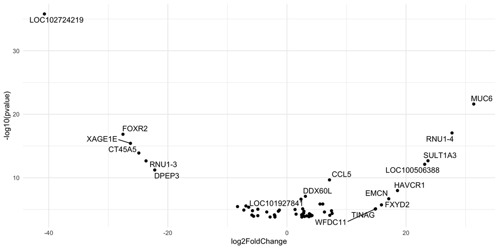

```r
res.filtered %>%
  ggplot(aes(x=log2FoldChange, y=-log10(pvalue), label=rownames(res.filtered))) +
  geom_point() +
  theme_minimal() +
  scale_color_manual(values = c("black", "blue", "red"))+
  geom_text_repel()
```

## Gene ontology

### GSEA of genes differentially expressed in resistant and sensitive lines

Perform gene set enrichment analysis using Cluster Profiler. This gives us GO pathways that are significantly regulated based on the log2fold change of expression of individual genes.

Using a padj Cutoff of 0.15.

```r
gene_list <- res$log2FoldChange
names(gene_list) <- rownames(res)
gene_list <- sort(gene_list, decreasing = TRUE)

# Set the seed so our results are reproducible:
set.seed(2024)
gsea_res <- gseGO(gene_list, ont = "BP", OrgDb = "org.Hs.eg.db", keyType = "SYMBOL", seed = TRUE, pvalueCutoff = 0.15)
```

```
using 'fgsea' for GSEA analysis, please cite Korotkevich et al (2019).

preparing geneSet collections...
GSEA analysis...
Warning in preparePathwaysAndStats(pathways, stats, minSize, maxSize, gseaParam,  :
  There are ties in the preranked stats (8.85% of the list).
The order of those tied genes will be arbitrary, which may produce unexpected results.
leading edge analysis...
done...
```

```r
# Format output
gsea_res_df <- as.data.frame(gsea_res)
gsea_res_df <- gsea_res_df %>%
  mutate(original_row_num = row_number())
gsea_res_df <- gsea_res_df[order(gsea_res_df$NES, decreasing = TRUE),]
row.names(gsea_res_df) <- gsea_res_df$ID
```

NES is the normalized enrichment score.

```r
gsea_res_df_short <- gsea_res_df[c("pvalue", "p.adjust", "NES", "Description")]
gsea_res_df_short$"core_enrichment_genes" <- gsea_res_df$core_enrichment
```

Volcano Plot of gene ontology (Average NES & adjusted p value)

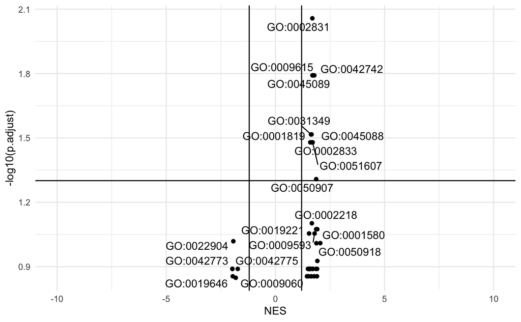

```r
as.data.frame(gsea_res_df_short) %>%
  ggplot(aes(x = NES, y = -log10(p.adjust), label = rownames(gsea_res_df_short))) +
  geom_point() +
  theme_minimal() +
  scale_color_manual(values = c("black", "blue", "red")) +
  geom_text_repel() +
  geom_hline(yintercept = 1.301) +
  geom_vline(xintercept = 1.2) +
  geom_vline(xintercept = -1.2) +
  xlim(-10, 10)
```

#### Upregulated pathways

```r
gsea_res_df_short.up <- subset(gsea_res_df_short, gsea_res_df_short$NES >= 0)
gsea_res_df_short.up = gsea_res_df_short.up[order(gsea_res_df_short.up$p.adjust), ]
path = paste0(deseq_output_folder,
              "/cisplatin_resistant_significantly_upregulated_pathways.csv")
write.csv(gsea_res_df_short.up, file = path)
gsea_res_df_short.up
```

|  | pvalue | p.adjust | NES | Description | core_enrichment_genes |
| --- | --- | --- | --- | --- | --- |
| GO:0002831 | 1.434740e-06 | 0.008760524 | 1.691351 | regulation of response to biotic stimulus | CLEC4E/IL1B/COLEC10/EREG/NLRP10/CCL5/NLRP1/IFNB1/MMP12/FCRL3/PIK3R6/TRIM22/IL4I1/RSAD2/MMRN2/S100A8/ISG15/HLA-G/IFI16/REG3G/DRD2/OAS1/TXK/SH2D1B/NR1H4/LY96/OASL/AIM2/PAK3/IFIH1/CD300A/CFH/TSPAN32/NFKB… |
| GO:0042742 | 1.058790e-05 | 0.016162429 | 1.779457 | defense response to bacterium | CLEC4E/WFDC11/IL1B/SELP/NLRP10/DEFB4A/SPRR2A/DEFB1/NLRP1/LTA…… |
| GO:0045089 | 9.324074e-06 | 0.016162429 | 1.711817 | positive regulation of innate immune response | CLEC4E/COLEC10/EREG/NLRP10/CCL5/NLRP1/IFNB1/MMP12/FCRL3/RSAD2/S100A8/HLA-G/IFI16/REG3G/OAS1/TXK/SH2D1B/NR1H4/LY96/OASL/AIM2/PAK3/IFIH1/CD300A/NFKBIZ/DDX60/TNIP3/OAS3/TLR1/BPIFB1/SLC46A2/IFI35/FOSL1/IR… |
| GO:0009615 | 7.656170e-06 | 0.016162429 | 1.695939 | response to virus | IL1B/CCL5/POU2F2/PTPRC/CXCL10/IFNL1/NLRP1/IFNB1/MMP12/WDFY4/…… |
| GO:0045088 | 2.823795e-05 | 0.030461793 | 1.653750 | regulation of innate immune response | CLEC4E/COLEC10/EREG/NLRP10/CCL5/NLRP1/IFNB1/MMP12/FCRL3/PIK3R6/RSAD2/S100A8/ISG15/HLA-G/IFI16/REG3G/DRD2/OAS1/TXK/SH2D1B/NR1H4/LY96/OASL/AIM2/PAK3/IFIH1/CD300A/CFH/NFKBIZ/LGALS9/DDX60/TNIP3/OAS3/TLR1/… |
| GO:0031349 | 2.993298e-05 | 0.030461793 | 1.629817 | positive regulation of defense response | CLEC4E/IL1B/COLEC10/EREG/NLRP10/CCL5/LGALS2/NLRP1/LTA/IFNB1/MMP12/FCRL3/PLA2G7/SERPINE1/RSAD2/MMRN2/S100A8/HLA-G/IFI16/REG3G/OAS1/TXK/SH2D1B/NR1H4/LY96/OASL/AIM2/PAK3/IFIH1/CCL3/CD300A/NEAT1/GPSM3/NFK… |
| GO:0051607 | 4.888088e-05 | 0.033162963 | 1.704362 | defense response to virus | IL1B/PTPRC/CXCL10/IFNL1/NLRP1/IFNB1/MMP12/DDX60L/OAS2/TRIM22…… |
| GO:0002833 | 4.722109e-05 | 0.033162963 | 1.661158 | positive regulation of response to biotic stimulus | CLEC4E/COLEC10/EREG/NLRP10/CCL5/NLRP1/IFNB1/MMP12/FCRL3/RSAD2/MMRN2/S100A8/HLA-G/IFI16/REG3G/OAS1/TXK/SH2D1B/NR1H4/LY96/OASL/AIM2/PAK3/IFIH1/CD300A/NFKBIZ/DDX60/TNIP3/OAS3/TLR1/BPIFB1/SLC46A2/IFI35/FO… |
| GO:0001819 | 3.848265e-05 | 0.033162963 | 1.595081 | positive regulation of cytokine production | CLEC4E/PAEP/IL1A/IL1B/EREG/NLRP10/CSF2/SAA1/POU2F2/PTPRC/IFNL1/NLRP1/LTA/GATA4/MMP12/LAPTM5/SERPINE1/OAS2/RSAD2/FCGR2A/ISG15/PRG2/HLA-G/IFI16/DRD2/FCGR2C/OAS1/TXK/TNFRSF8/NR1H4/LY96/AIM2/IFIH1/CCL3/SE… |
| GO:0050907 | 8.060497e-05 | 0.049217393 | 1.867067 | detection of chemical stimulus involved in sensory perception | OR3A2/CST2/PIGR/AZGP1/OR3A1/OR10AD1/OR4C6/TAS2R43/PIP/OR1Q1/…… |

[output cut: 24 more lines]

Use Revigo to cluster upregulated pathways with pvalue < 0.15

```r
revigo_input.cellline.up <- gsea_res_df_short.up[gsea_res_df_short.up$p.adjust < 0.15,][c("p.adjust")]
rownames(revigo_input.cellline.up) <- rownames(gsea_res_df_short.up[gsea_res_df_short.up$p.adjust < 0.15,])

simMatrix <- calculateSimMatrix(rownames(revigo_input.cellline.up),
  orgdb = "org.Hs.eg.db",
  ont = "BP",
  method = "Rel"
)
scores <- setNames(-log10(revigo_input.cellline.up$p.adjust), rownames(revigo_input.cellline.up))

if (nrow(revigo_input.cellline.up) > 1) {
  reducedTerms <- reduceSimMatrix(simMatrix,
    scores,
    threshold = 0.7,
    orgdb = "org.Hs.eg.db"
  )
} else {
  reducedTerms <- data.frame(matrix(ncol = 0, nrow = 0))
  print("There will be no graphs appearing below this because there were not enough significantly upregulated pathways to meaningfully cluster them")
}
```

Revigo treemap plot. Terms grouped/colored based on parent. Space is proportional to statistical significance of the GO term (-log10(pvalue)).

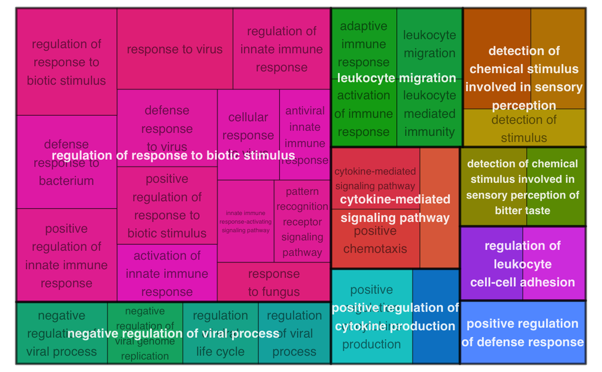

```r
if (nrow(reducedTerms) > 2) {
  treemapPlot(reducedTerms)
}
```

Use Revigo to cluster upregulated pathways with pvalue < 0.05

```r
revigo_input.cellline.up <- gsea_res_df_short.up[gsea_res_df_short.up$p.adjust < 0.05,][c("p.adjust")]
rownames(revigo_input.cellline.up) <- rownames(gsea_res_df_short.up[gsea_res_df_short.up$p.adjust < 0.05,])

simMatrix <- calculateSimMatrix(rownames(revigo_input.cellline.up),
  orgdb = "org.Hs.eg.db",
  ont = "BP",
  method = "Rel"
)
scores <- setNames(-log10(revigo_input.cellline.up$p.adjust), rownames(revigo_input.cellline.up))

if (nrow(revigo_input.cellline.up) > 1) {
  reducedTerms <- reduceSimMatrix(simMatrix,
    scores,
    threshold = 0.7,
    orgdb = "org.Hs.eg.db"
  )
} else {
  reducedTerms <- data.frame(matrix(ncol = 0, nrow = 0))
  print("There will be no graphs appearing below this because there were not enough significantly upregulated pathways to meaningfully cluster them")
}
```

Revigo treemap plot. Terms grouped/colored based on parent. Space is proportional to statistical significance of the GO term (-log10(pvalue)).

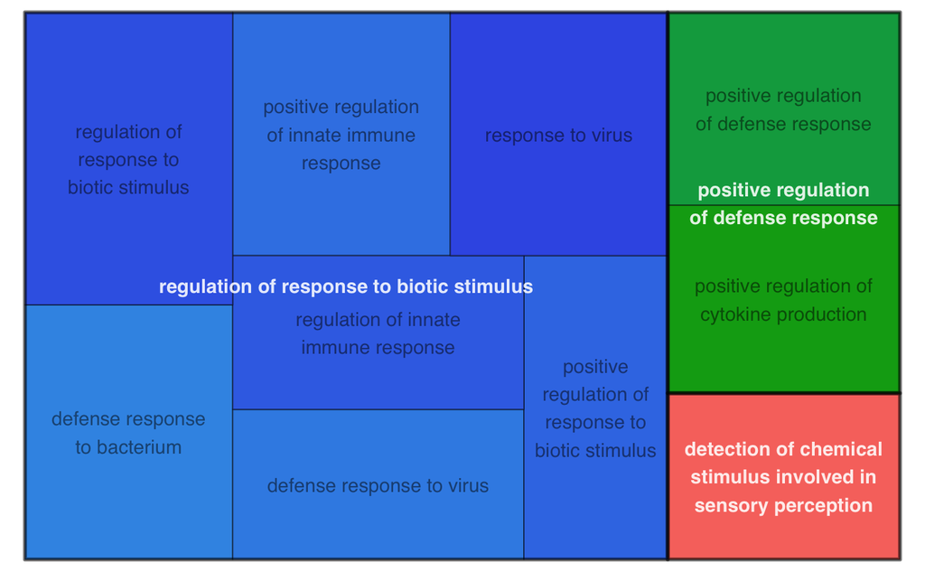

```r
if (nrow(reducedTerms) > 2) {
  treemapPlot(reducedTerms)
}
```

#### Downregulated pathways

```r
gsea_res_df_short.down <- subset(gsea_res_df_short, gsea_res_df_short$NES <= 0)
path = paste0(deseq_output_folder,
              "/cisplatin_resistant_significantly_downregulated_pathways.csv")
write.csv(gsea_res_df_short.down, file = path)
gsea_res_df_short.down
```

|  | pvalue | p.adjust | NES | Description | core_enrichment_genes |
| --- | --- | --- | --- | --- | --- |
| GO:0045333 | 0.0005729727 | 0.12890633 | -1.725047 | cellular respiration | FH/NDUFB6/COX15/NDUFB4/AIFM2/COQ10A/IDH3A/COQ9/NDUFB2/CDK1/N…… |
| GO:0009060 | 0.0009289855 | 0.14180963 | -1.818429 | aerobic respiration | FH/NDUFB6/COX15/NDUFB4/IDH3A/COQ9/NDUFB2/CDK1/NDUFAF1/NDUFA4…… |
| GO:0022904 | 0.0002510820 | 0.09581917 | -1.928212 | respiratory electron transport chain | NDUFB6/COX15/NDUFB4/AIFM2/COQ9/NDUFB2/CDK1/NDUFAF1/NDUFA4/SD…… |
| GO:0019646 | 0.0008268399 | 0.13958643 | -1.955442 | aerobic electron transport chain | NDUFB6/COX15/NDUFB4/COQ9/NDUFB2/NDUFAF1/NDUFA4/SDHC/UQCR10/N…… |
| GO:0042773 | 0.0005394787 | 0.12890633 | -1.972678 | ATP synthesis coupled electron transport | NDUFB6/COX15/NDUFB4/COQ9/NDUFB2/CDK1/NDUFAF1/NDUFA4/SDHC/UQC…… |
| GO:0042775 | 0.0005394787 | 0.12890633 | -1.972678 | mitochondrial ATP synthesis coupled electron transport | NDUFB6/COX15/NDUFB4/COQ9/NDUFB2/CDK1/NDUFAF1/NDUFA4/SDHC/UQC…… |

Use Revigo to cluster downregulated pathways with pvalue < 0.15

```r
revigo_input.cellline.down <- gsea_res_df_short.down[gsea_res_df_short.down$p.adjust < 0.15,][c("p.adjust")]
rownames(revigo_input.cellline.down) <- rownames(gsea_res_df_short.down[gsea_res_df_short.down$p.adjust < 0.15,])

simMatrix <- calculateSimMatrix(rownames(revigo_input.cellline.down),
  orgdb = "org.Hs.eg.db",
  ont = "BP",
  method = "Rel"
)
scores <- setNames(-log10(revigo_input.cellline.down$p.adjust), rownames(revigo_input.cellline.down))

if (nrow(revigo_input.cellline.down) > 1) {
  reducedTerms <- reduceSimMatrix(simMatrix,
    scores,
    threshold = 0.7,
    orgdb = "org.Hs.eg.db"
  )
} else {
  reducedTerms <- data.frame(matrix(ncol = 0, nrow = 0))
  print("There will be no graphs appearing below this because there were not enough significantly upregulated pathways to meaningfully cluster them")
}
```

Revigo treemap plot. Terms grouped/colored based on parent. Space is proportional to statistical significance of the GO term (-log10(pvalue)).

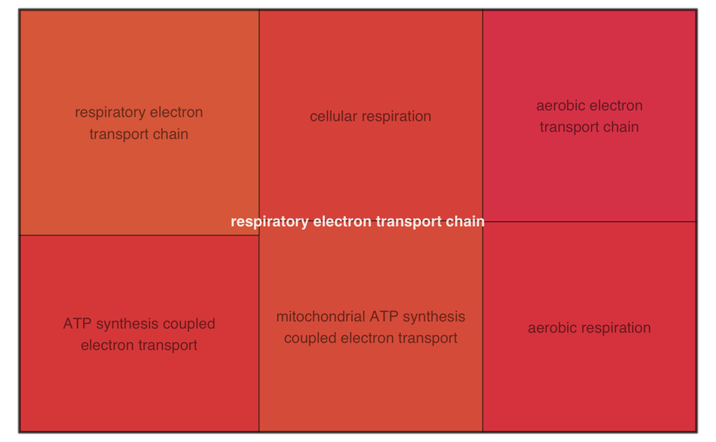

```r
if (nrow(reducedTerms) > 2) {
  treemapPlot(reducedTerms)
}
```